## ML Case Study - Hospital Readmission Prediction

### Objective:

#### Investigate and identify key factors contributing to hospital readmissions, which occur when patients are readmitted to the hospital shortly after discharge. By analyzing these factors, the goal is to develop predictive models that can assist in anticipating which patients are more likely to experience readmission.

### Import Libraries

```r
library(dplyr)
library(ggplot2)
library(caret)
library(ROCR)
library(e1071)
library(car)
```

### Import Data

```r
data <- read.csv('Hospital Readmissions.csv')
head(data)
```

```
  id     age time_in_hospital n_lab_procedures n_procedures n_medications
1  1 [70-80)                8               72            1            18
2  2 [70-80)                3               34            2            13
3  3 [50-60)                5               45            0            18
4  4 [70-80)                2               36            0            12
5  5 [60-70)                1               42            0             7
6  6 [40-50)                2               51            0            10
  n_outpatient n_inpatient n_emergency   diagnosis glucose_test A1Ctest change
1            2           0           0 Circulatory           no      no     no
2            0           0           0       Other           no      no     no
3            0           0           0 Circulatory           no      no    yes
4            1           0           0 Circulatory           no      no    yes
5            0           0           0       Other           no      no     no
6            0           0           0       Other           no      no     no
  diabetes_med readmitted
1          yes         no
2          yes         no
3          yes        yes
4          yes        yes
5          yes         no
6           no        yes
```

### Data Description

| Field | Description |
| --- | --- |
| age | Age bracket of the patient |
| time_in_hospital | Days (from 1 to 14) |
| n_procedures | Number of procedures performed during the hospital stay |
| n_lab_procedures | Number of laboratory procedures during the hospital stay |
| n_medications | Number of medications administered during the hospital stay |
| n_outpatient | Number of outpatient visits in the year before a hospital stay |
| n_inpatient | Number of inpatient visits in the year before the hospital stay |
| n_emergency | Number of visits to the emergency room in the year before the hospital stay |
| diagnosis | Primary diagnosis (Circulatory, Respiratory, Digestive, etc.) |
| glucose_test | Whether the glucose serum came out as high (> 200), normal, or not performed |
| A1Ctest | Whether the A1C level of the patient came out as high (> 7%), normal, or not performed |
| change | Whether there was a change in the diabetes medication ('yes' or 'no') |
| diabetes_med | Whether a diabetes medication was prescribed ('yes' or 'no') |
| readmitted | If the patient was readmitted at the hospital ('yes' or 'no') |

#### **Converting data types (Required for modelling)**

```r
data$readmitted <- ifelse(data$readmitted=="no",0,1)
data$readmitted<-as.factor(data$readmitted)
```

```r
# Convert selected columns to factors

data <- data %>%
  mutate_at(vars(c('age','diagnosis','glucose_test','A1Ctest','change','diabetes_med')), ~as.factor(.))
```

### Hospital Readmission Status Overview: Visualisation

#### **1. Pie Chart showing % readmission**

```r
# Count the occurrences of each value in the 'readmitted' column

readmitted_counts <-data.frame(table(data$readmitted))

readmitted_counts$Percent <- readmitted_counts$Freq / sum(readmitted_counts$Freq) * 100

readmitted_counts
```

```
  Var1  Freq Percent
1    0 13246  52.984
2    1 11754  47.016
```

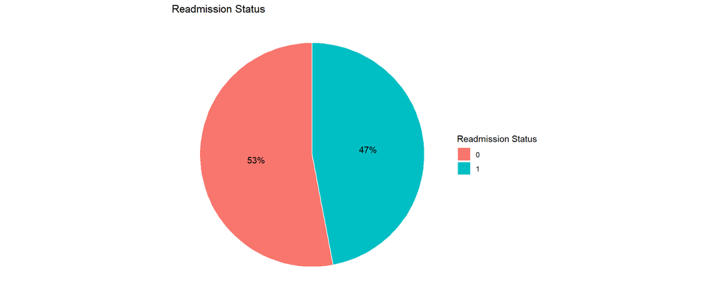

```r
# Create a pie chart

ggplot(readmitted_counts, aes(x = "", y = Freq, fill = Var1)) +
  geom_bar(stat = "identity", width = 1, color = "white") +
  coord_polar("y") +
  theme_void() +
  geom_text(aes(label = paste0(round(Percent, 1), "%")), position = position_stack(vjust = 0.5)) +
  labs(title = "Readmission Status",
       fill = "Readmission Status")
```

#### **2. Boxplot for Number of lab procedures during the hospital stay, Stratified by Readmission Status**

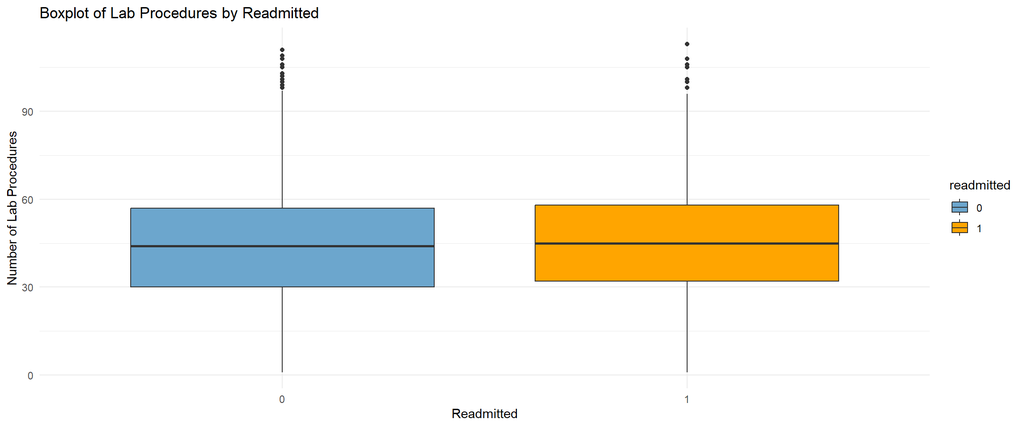

```r
ggplot(data, aes(x = readmitted, y = n_lab_procedures, fill = readmitted)) +
  geom_boxplot() +
  labs(title = "Boxplot of Lab Procedures by Readmitted",
       x = "Readmitted",
       y = "Number of Lab Procedures") +
  scale_fill_manual(values = c("0" = "skyblue3", "1" = "orange")) +
  theme_minimal()
```

#### **3. Bar Graph Illustrating the Percentage of Readmitted Cases Across Different Age Groups**

```r
grouped_data <-data %>%
  group_by(age,readmitted) %>%
  summarise(count = n())%>%
  mutate(percent = count / sum(count))

head(grouped_data)
```

```
# A tibble: 6 × 4
# Groups:   age [3]
  age     readmitted count percent
  <fct>   <fct>      <int>   <dbl>
1 [40-50) 0           1405   0.555
2 [40-50) 1           1127   0.445
3 [50-60) 0           2486   0.558
4 [50-60) 1           1966   0.442
5 [60-70) 0           3143   0.532
6 [60-70) 1           2770   0.468
```

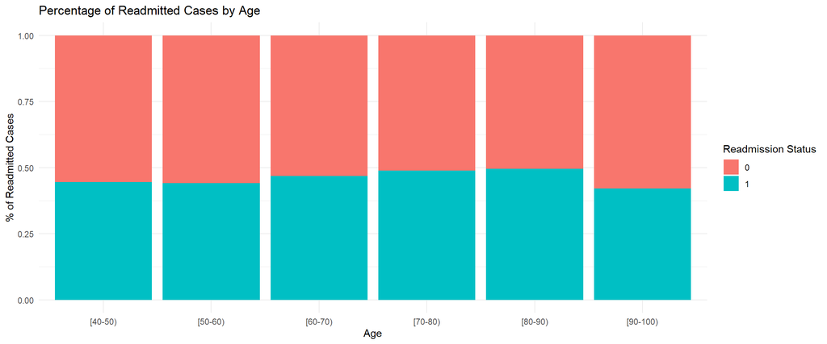

```r
ggplot(grouped_data, aes(x = age, y = percent, fill = readmitted)) +
  geom_bar(stat = "identity") +
  labs(title = "Percentage of Readmitted Cases by Age",
       x = "Age",
       y = "% of Readmitted Cases",
       fill = "Readmission Status") +
  theme_minimal()
```

#### **4. Bar Graph Illustrating the Percentage of Readmitted Cases Across Different Diagnosis**

```r
grouped_data <- data %>%
  group_by(diagnosis, readmitted) %>%
  summarise(count = n())%>%
  mutate(percent = count / sum(count))

head(grouped_data)
```

```
# A tibble: 6 × 4
# Groups:   diagnosis [3]
  diagnosis   readmitted count percent
  <fct>       <fct>      <int>   <dbl>
1 Circulatory 0           4074   0.521
2 Circulatory 1           3750   0.479
3 Diabetes    0            810   0.464
4 Diabetes    1            937   0.536
5 Digestive   0           1224   0.526
6 Digestive   1           1105   0.474
```

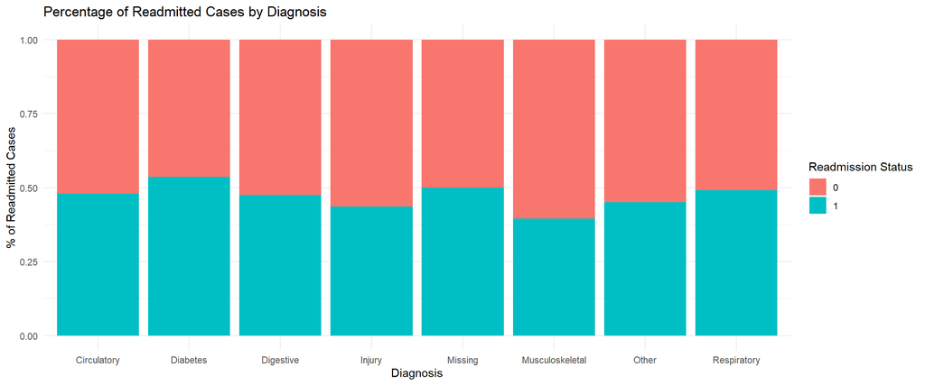

```r
ggplot(grouped_data, aes(x = diagnosis, y = percent, fill = readmitted)) +
  geom_bar(stat = "identity") +
  labs(title = "Percentage of Readmitted Cases by Diagnosis",
       x = "Diagnosis",
       y = "% of Readmitted Cases",
       fill = "Readmission Status") +
  theme_minimal()
```

### Model 1. Binary Logistic Regression

#### Splitting Data into Train and Test data sets

```r
index<-createDataPartition(data$readmitted,p=0.7,list=FALSE)

traindata<-data[index,]
testdata<-data[-index,]

threshold = 0.45
```

#### Building Model

```r
model<-glm(readmitted~age+ time_in_hospital+ n_lab_procedures+ n_procedures+n_medications+ n_outpatient+ n_inpatient+
             n_emergency+ diagnosis+ glucose_test+ A1Ctest+ change+ diabetes_med,data = traindata,family=binomial)

summary(model)
```

```
Call:
glm(formula = readmitted ~ age + time_in_hospital + n_lab_procedures +
    n_procedures + n_medications + n_outpatient + n_inpatient +
    n_emergency + diagnosis + glucose_test + A1Ctest + change +
    diabetes_med, family = binomial, data = traindata)

Coefficients:
                           Estimate Std. Error z value Pr(>|z|)
(Intercept)              -0.7301138  0.1295024  -5.638 1.72e-08 ***
age[50-60)                0.0201317  0.0630739   0.319 0.749593
age[60-70)                0.1313694  0.0603826   2.176 0.029584 *
age[70-80)                0.1696724  0.0594315   2.855 0.004305 **
age[80-90)                0.2254519  0.0634003   3.556 0.000377 ***
age[90-100)              -0.0136495  0.1048416  -0.130 0.896415
time_in_hospital          0.0179593  0.0061833   2.904 0.003679 **
n_lab_procedures          0.0008587  0.0009026   0.951 0.341384
n_procedures             -0.0330998  0.0103997  -3.183 0.001459 **
n_medications            -0.0001373  0.0024950  -0.055 0.956125
n_outpatient              0.1379745  0.0161890   8.523  < 2e-16 ***
n_inpatient               0.3855530  0.0172984  22.288  < 2e-16 ***
n_emergency               0.2159091  0.0303123   7.123 1.06e-12 ***
diagnosisDiabetes         0.0982617  0.0685879   1.433 0.151961
diagnosisDigestive       -0.0859857  0.0591616  -1.453 0.146111
diagnosisInjury          -0.2187420  0.0664735  -3.291 0.001000 ***
diagnosisMissing          0.6711891  1.2417804   0.541 0.588848
diagnosisMusculoskeletal -0.3033886  0.0778656  -3.896 9.77e-05 ***
diagnosisOther           -0.2104294  0.0432049  -4.870 1.11e-06 ***
diagnosisRespiratory     -0.0223815  0.0512251  -0.437 0.662166
glucose_testno           -0.0157440  0.0962375  -0.164 0.870050
glucose_testnormal       -0.0414655  0.1356639  -0.306 0.759872
A1Ctestno                 0.0264106  0.0518902   0.509 0.610772
A1Ctestnormal            -0.0985485  0.0840775  -1.172 0.241151
changeyes                 0.0390466  0.0372199   1.049 0.294142
diabetes_medyes           0.2366687  0.0435233   5.438 5.40e-08 ***
---
Signif. codes:  0 '***' 0.001 '**' 0.01 '*' 0.05 '.' 0.1 ' ' 1

(Dispersion parameter for binomial family taken to be 1)

    Null deviance: 24199  on 17500  degrees of freedom
Residual deviance: 23008  on 17475  degrees of freedom
AIC: 23060

Number of Fisher Scoring iterations: 4
```

#### Checking Multicollinearity

```r
vif(model)
```

```
##                      GVIF Df GVIF^(1/(2*Df))
## age              1.094017  5        1.009026
## time_in_hospital 1.399097  1        1.182834
## n_lab_procedures 1.303525  1        1.141720
## n_procedures     1.314325  1        1.146440
## n_medications    1.642583  1        1.281633
## n_outpatient     1.030920  1        1.015343
## n_inpatient      1.062232  1        1.030646
## n_emergency      1.048040  1        1.023738
## diagnosis        1.261348  7        1.016723
## glucose_test     1.066129  2        1.016137
## A1Ctest          1.126373  2        1.030198
## change           1.403656  1        1.184760
## diabetes_med     1.352310  1        1.162889
```

None of the GVIF values are greater than 5, meaning there is no Multicollinearity.

#### Removing insignificant variables and running the model again

Removed: change, glucose_test

```r
model<-glm(readmitted ~ age+ time_in_hospital+ n_lab_procedures+ n_procedures+n_medications+
             n_outpatient+ n_inpatient+ n_emergency+ diagnosis + A1Ctest + diabetes_med,
           data = traindata,family=binomial)
summary(model)
```

```
##
## Call:
## glm(formula = readmitted ~ age + time_in_hospital + n_lab_procedures +
##     n_procedures + n_medications + n_outpatient + n_inpatient +
##     n_emergency + diagnosis + A1Ctest + diabetes_med, family = binomial,
##     data = traindata)
##
## Coefficients:
##                            Estimate Std. Error z value Pr(>|z|)
## (Intercept)              -0.7472235  0.0912437  -8.189 2.63e-16 ***
## age[50-60)                0.0187057  0.0630533   0.297 0.766723
## age[60-70)                0.1302196  0.0603679   2.157 0.030998 *
## age[70-80)                0.1673550  0.0593924   2.818 0.004836 **
## age[80-90)                0.2226889  0.0633398   3.516 0.000438 ***
## age[90-100)              -0.0158315  0.1048020  -0.151 0.879928
## time_in_hospital          0.0180831  0.0061714   2.930 0.003388 **
## n_lab_procedures          0.0008595  0.0008873   0.969 0.332741
## n_procedures             -0.0336821  0.0103477  -3.255 0.001134 **
## n_medications             0.0003015  0.0024570   0.123 0.902337
## n_outpatient              0.1379666  0.0161405   8.548  < 2e-16 ***
## n_inpatient               0.3852276  0.0172960  22.273  < 2e-16 ***
## n_emergency               0.2165937  0.0303047   7.147 8.86e-13 ***
## diagnosisDiabetes         0.1021257  0.0684992   1.491 0.135987
## diagnosisDigestive       -0.0876280  0.0591339  -1.482 0.138379
## diagnosisInjury          -0.2186185  0.0664559  -3.290 0.001003 **
## diagnosisMissing          0.6654692  1.2418471   0.536 0.592048
## diagnosisMusculoskeletal -0.3040435  0.0777952  -3.908 9.30e-05 ***
## diagnosisOther           -0.2101415  0.0431968  -4.865 1.15e-06 ***
## diagnosisRespiratory     -0.0212437  0.0511897  -0.415 0.678142
## A1Ctestno                 0.0230379  0.0517851   0.445 0.656410
## A1Ctestnormal            -0.1032079  0.0839635  -1.229 0.218997
## diabetes_medyes           0.2582780  0.0385887   6.693 2.18e-11 ***
## ---
## Signif. codes:  0 '***' 0.001 '**' 0.01 '*' 0.05 '.' 0.1 ' ' 1
##
## (Dispersion parameter for binomial family taken to be 1)
##
##     Null deviance: 24199  on 17500  degrees of freedom
## Residual deviance: 23010  on 17478  degrees of freedom
## AIC: 23056
##
## Number of Fisher Scoring iterations: 4
```

### Computing Train - AUC value for ROC curve

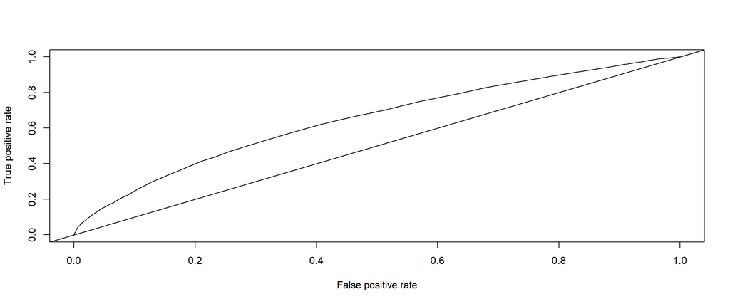

```r
traindata$predprob<- round(fitted(model),2)
predtrain<-prediction(traindata$predprob, traindata$readmitted)
perftrain<-performance(predtrain,"tpr","fpr")
plot(perftrain)
abline(0,1)
```

```r
#AUC
auc<-performance(predtrain,"auc")
auc@y.values
```

```
[[1]]
[1] 0.6465872
```

#### Confusion Matrix for Train data

```r
# Predicted Y for train data
traindata$predY<-as.factor(ifelse(traindata$predprob > threshold,1,0))

#Train data confusion Matrix
confusionMatrix(traindata$predY, as.factor(traindata$readmitted),positive="1")
```

```
Confusion Matrix and Statistics

          Reference
Prediction    0    1
         0 6299 3821
         1 2974 4407

               Accuracy : 0.6117
                 95% CI : (0.6045, 0.619)
    No Information Rate : 0.5299
    P-Value [Acc > NIR] : < 2.2e-16

                  Kappa : 0.2161

 Mcnemar's Test P-Value : < 2.2e-16

            Sensitivity : 0.5356
            Specificity : 0.6793
         Pos Pred Value : 0.5971
         Neg Pred Value : 0.6224
             Prevalence : 0.4701
         Detection Rate : 0.2518
   Detection Prevalence : 0.4217
      Balanced Accuracy : 0.6074

       'Positive' Class : 1
```

#### Computing Test - AUC value for ROC curve

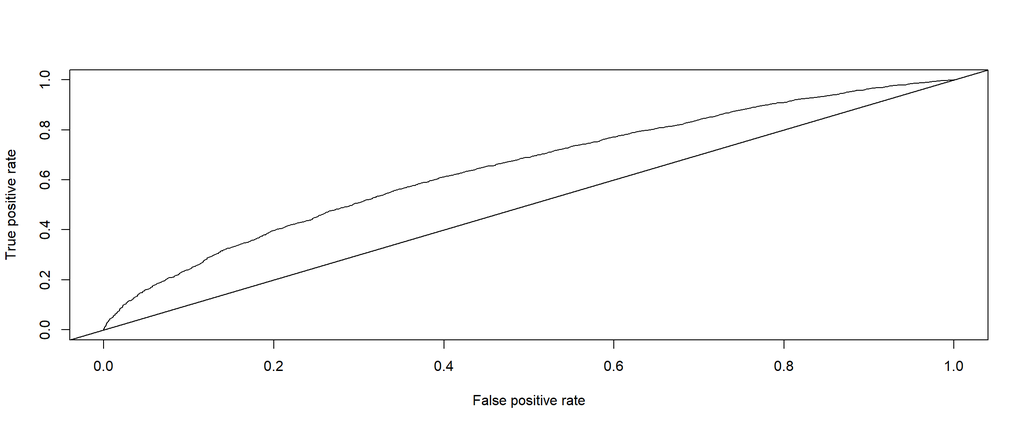

```r
testdata$predprob<-predict(model,testdata,type='response')
pred<-prediction(testdata$predprob,testdata$readmitted)
perf<-performance(pred,"tpr","fpr")
plot(perf)
abline(0,1)
```

```r
auc<-performance(pred,"auc")
auc@y.values
```

```
[[1]]
[1] 0.6476067
```

#### Confusion Matrix for Test data

```r
testdata$predY<- as.factor(ifelse(testdata$predprob > threshold,1,0))
confusionMatrix(testdata$predY,testdata$readmitted,positive="1")
```

```
Confusion Matrix and Statistics

          Reference
Prediction    0    1
         0 2595 1544
         1 1378 1982

               Accuracy : 0.6103
                 95% CI : (0.5992, 0.6214)
    No Information Rate : 0.5298
    P-Value [Acc > NIR] : < 2e-16

                  Kappa : 0.2158

 Mcnemar's Test P-Value : 0.00227

            Sensitivity : 0.5621
            Specificity : 0.6532
         Pos Pred Value : 0.5899
         Neg Pred Value : 0.6270
             Prevalence : 0.4702
         Detection Rate : 0.2643
   Detection Prevalence : 0.4481
      Balanced Accuracy : 0.6076

       'Positive' Class : 1
```

### Model 2. Naive Bayes

#### Building Model

```r
model_nb<-naiveBayes(readmitted~age+ time_in_hospital+ n_lab_procedures+ n_procedures+n_medications+ n_outpatient+ n_inpatient+n_emergency+ diagnosis+ glucose_test+ A1Ctest+ change+ diabetes_med,data = traindata)
```

#### Predicting probabilities and Computing train - AUC value for ROC curve

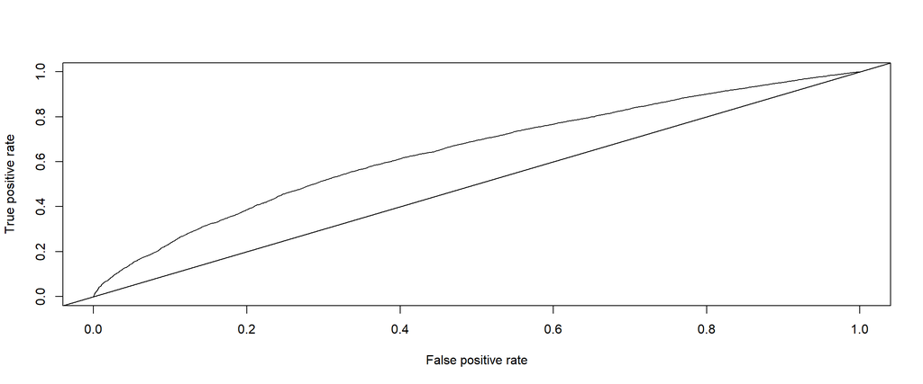

```r
prednb<-predict(model_nb,traindata,type='raw')

#### Computing AUC value for ROC curve
pred<-prediction(prednb[,2],traindata$readmitted)
perf<-performance(pred,"tpr","fpr")
plot(perf)
abline(0,1)
```

```r
auc<-performance(pred,"auc")
auc@y.values
```

```
[[1]]
[1] 0.6435296
```

#### Confusion Matrix for train data

```r
traindata$predY<-as.factor(ifelse(prednb[,2] > threshold,1,0))
confusionMatrix(traindata$predY,traindata$readmitted,positive="1")
```

```
Confusion Matrix and Statistics

          Reference
Prediction    0    1
         0 8226 6059
         1 1047 2169

               Accuracy : 0.594
                 95% CI : (0.5866, 0.6013)
    No Information Rate : 0.5299
    P-Value [Acc > NIR] : < 2.2e-16

                  Kappa : 0.1561

 Mcnemar's Test P-Value : < 2.2e-16

            Sensitivity : 0.2636
            Specificity : 0.8871
         Pos Pred Value : 0.6744
         Neg Pred Value : 0.5758
             Prevalence : 0.4701
         Detection Rate : 0.1239
   Detection Prevalence : 0.1838
      Balanced Accuracy : 0.5754

       'Positive' Class : 1
```

#### Predicting probabilities and Computing test - AUC value for ROC curve

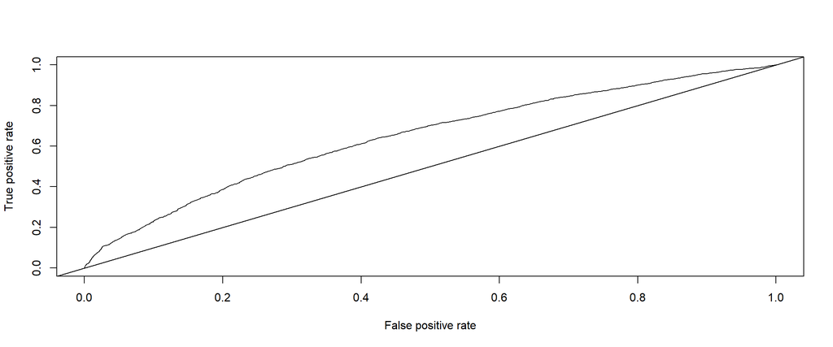

```r
prednb<-predict(model_nb,testdata,type='raw')
#### Computing AUC value for ROC curve
pred<-prediction(prednb[,2],testdata$readmitted)
perf<-performance(pred,"tpr","fpr")
plot(perf)
abline(0,1)
```

```r
auc<-performance(pred,"auc")
auc@y.values
```

```
[[1]]
[1] 0.6449524
```

#### Confusion Matrix for test data

```r
testdata$predY<-as.factor(ifelse(prednb[,2] > threshold,1,0))
confusionMatrix(testdata$predY,testdata$readmitted,positive="1")
```

```
Confusion Matrix and Statistics

          Reference
Prediction    0    1
         0 3500 2613
         1  473  913

               Accuracy : 0.5885
                 95% CI : (0.5772, 0.5996)
    No Information Rate : 0.5298
    P-Value [Acc > NIR] : < 2.2e-16

                  Kappa : 0.1448

 Mcnemar's Test P-Value : < 2.2e-16

            Sensitivity : 0.2589
            Specificity : 0.8809
         Pos Pred Value : 0.6587
         Neg Pred Value : 0.5726
             Prevalence : 0.4702
         Detection Rate : 0.1217
   Detection Prevalence : 0.1848
      Balanced Accuracy : 0.5699

       'Positive' Class : 1
```

##### Note:

Threshold can be adjusted to maximize the sensitivity and specificity

### Model 3. Support Vector Machine (SVM)

#### Building Model

```r
model_svm<-svm(readmitted~age+ time_in_hospital+ n_lab_procedures+ n_procedures+n_medications+ n_outpatient+
                 n_inpatient+n_emergency+ diagnosis+ glucose_test+ A1Ctest+ change+ diabetes_med,data = traindata,
               type="C",probability=TRUE,kernel="linear")
model_svm
```

```
Call:
svm(formula = readmitted ~ age + time_in_hospital + n_lab_procedures +
    n_procedures + n_medications + n_outpatient + n_inpatient + n_emergency +
    diagnosis + glucose_test + A1Ctest + change + diabetes_med, data = traindata,
    type = "C", probability = TRUE, kernel = "linear")


Parameters:
   SVM-Type:  C-classification
 SVM-Kernel:  linear
       cost:  1

Number of Support Vectors:  14938
```

#### Predicting probabilities and Computing train - AUC value for ROC curve

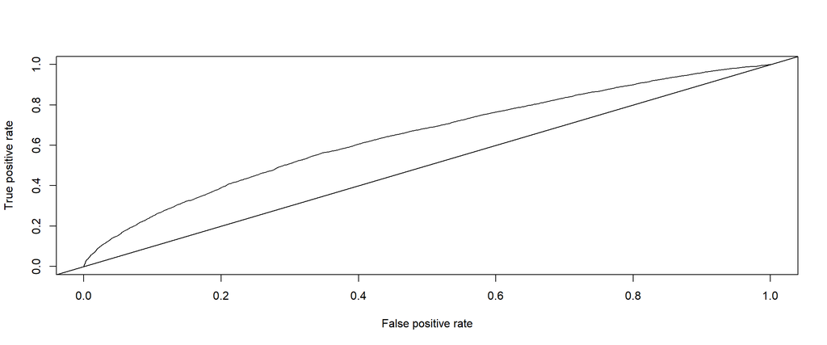

```r
pred1<-predict(model_svm,traindata,probability=TRUE)
pred2<-attr(pred1,"probabilities")[,2]

# Computing AUC value for ROC curve
pred<-prediction(pred2,traindata$readmitted)
perf<-performance(pred,"tpr","fpr")
plot(perf)
abline(0,1)
```

```r
auc<-performance(pred,"auc")
auc@y.values
```

```
[[1]]
[1] 0.6432292
```

#### Confusion Matrix for train data

```r
traindata$predY<-as.factor(ifelse(pred2>threshold,1,0))
confusionMatrix(traindata$predY,traindata$readmitted,positive="1")
```

```
Confusion Matrix and Statistics

          Reference
Prediction    0    1
         0 6551 4097
         1 2722 4131

               Accuracy : 0.6104
                 95% CI : (0.6031, 0.6176)
    No Information Rate : 0.5299
    P-Value [Acc > NIR] : < 2.2e-16

                  Kappa : 0.2105

 Mcnemar's Test P-Value : < 2.2e-16

            Sensitivity : 0.5021
            Specificity : 0.7065
         Pos Pred Value : 0.6028
         Neg Pred Value : 0.6152
             Prevalence : 0.4701
         Detection Rate : 0.2360
   Detection Prevalence : 0.3916
      Balanced Accuracy : 0.6043

       'Positive' Class : 1
```

#### Predicting probabilities and Computing test - AUC value for ROC curve

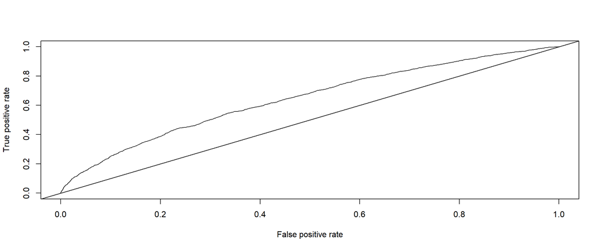

```r
pred1<-predict(model_svm,testdata,probability=TRUE)
pred2<-attr(pred1,"probabilities")[,2]

# Computing AUC value for ROC curve
pred<-prediction(pred2,testdata$readmitted)
perf<-performance(pred,"tpr","fpr")
plot(perf)
abline(0,1)
```

```r
auc<-performance(pred,"auc")
auc@y.values
```

```
[[1]]
[1] 0.6436452
```

#### Generate Confusion Matrix

```r
testdata$predY<-as.factor(ifelse(pred2>threshold,1,0))
confusionMatrix(testdata$predY,testdata$readmitted,positive="1")
```

```
Confusion Matrix and Statistics

          Reference
Prediction    0    1
         0 2786 1766
         1 1187 1760

               Accuracy : 0.6062
                 95% CI : (0.595, 0.6173)
    No Information Rate : 0.5298
    P-Value [Acc > NIR] : < 2.2e-16

                  Kappa : 0.2023

 Mcnemar's Test P-Value : < 2.2e-16

            Sensitivity : 0.4991
            Specificity : 0.7012
         Pos Pred Value : 0.5972
         Neg Pred Value : 0.6120
             Prevalence : 0.4702
         Detection Rate : 0.2347
   Detection Prevalence : 0.3930
      Balanced Accuracy : 0.6002

       'Positive' Class : 1
```